# HW06

Noah Dunn

November 5, 2018

# Problem 1

```r
ratData <- read.csv("ratlethargy.csv", header=TRUE)
```

## 1.

```r
ratData.anova <- aov(resttime ~ dose, data = ratData)
summary(ratData.anova)
```

```
##             Df Sum Sq Mean Sq F value Pr(>F)
## dose         1 170551  170551   179.3 <2e-16 ***
## Residuals   58  55178     951
## ---
## Signif. codes:  0 '***' 0.001 '**' 0.01 '*' 0.05 '.' 0.1 ' ' 1
```

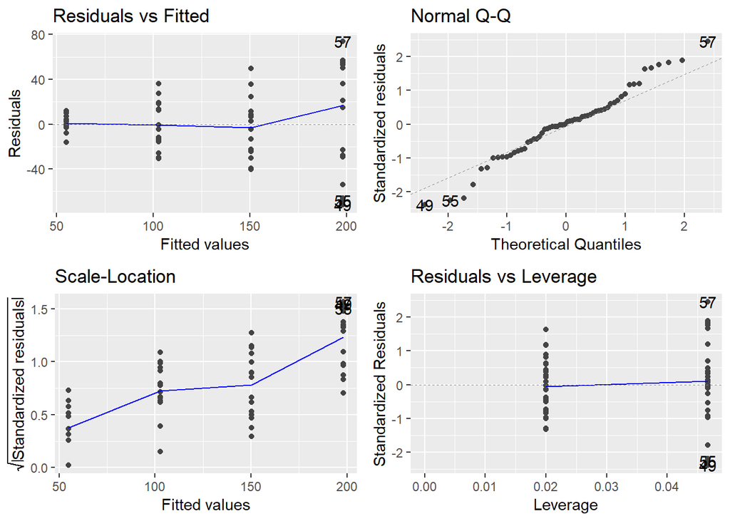

```r
autoplot(ratData.anova)
```

The initial observation is that dose does appear to be a significant predictor for Rest Time in the rats. Normality appears relatively okay, and we shouldn’t have to worry about any independence issues as these are all different rats. The equal variance of residuls assumption is however, something to be concerned with. Serious fanning can be observed as the fitted values proceed from left to right.

## 2.

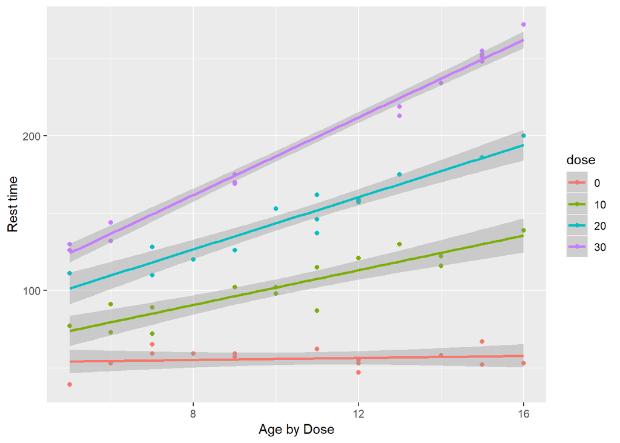

```r
ratData <- ratData %>%
  mutate(dose = as.factor(dose))
ggplot(ratData, aes(x=age, y=resttime, color = dose)) +
  geom_point() +
  xlab("Age by Dose") +
  ylab("Rest time")+
  geom_smooth(method = lm)
```

For three of the four levels of dosage(10mg, 20mg, 30mg), rest time appears to increase as the age of a given rat increases. The larger the dose of the drug given, the longer the rest time is at any given age for a rat, among these three groups. The slope of each line, or the rate at which rest time increases as age increases also appear to increase with increasing levels of dosage.

## 3.

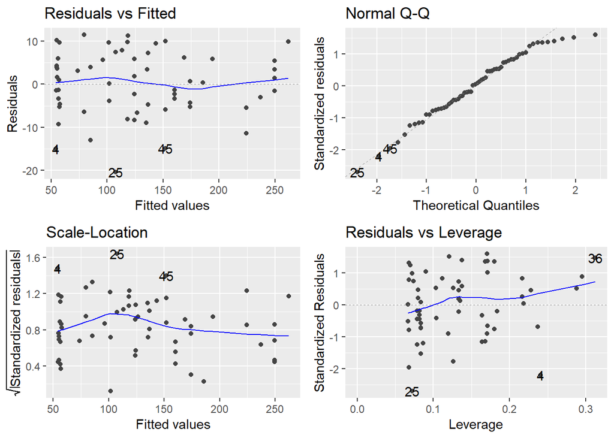

```r
ratData.ancova <- lm(resttime ~ dose + age + dose:age, data = ratData)
autoplot(ratData.ancova)
```

Normality, Equal Variance, and Independence are all now seemingly sound and properly established with little worry. The lack of the interaction term and age is likely what was causing such obscene error in the residuals vs fitted.

## 4.

```r
ratData.fakeancova <- lm(resttime ~ dose + age, data = ratData)
anova(ratData.fakeancova, ratData.ancova)
```

```
## Analysis of Variance Table
##
## Model 1: resttime ~ dose + age
## Model 2: resttime ~ dose + age + dose:age
##   Res.Df     RSS Df Sum of Sq      F    Pr(>F)
## 1     55 18986.9
## 2     52  3236.9  3     15750 84.339 < 2.2e-16 ***
## ---
## Signif. codes:  0 '***' 0.001 '**' 0.01 '*' 0.05 '.' 0.1 ' ' 1
```

At a p-value of 2.2 x 10^-16, there is a significant difference between these two models at any reasonable confidence level. For this test, our F statistic value is 84.339, and and our Degrees of freedom for the overall comparison is 3 and 52.

## 5.

```r
summary(ratData.ancova)
```

```
##
## Call:
## lm(formula = resttime ~ dose + age + dose:age, data = ratData)
##
## Residuals:
##      Min       1Q   Median       3Q      Max
## -20.5034  -4.8479   0.5198   5.8680  11.5503
##
## Coefficients:
##             Estimate Std. Error t value Pr(>|t|)
## (Intercept)  52.4461     6.5917   7.956 1.49e-10 ***
## dose10       -6.6609     9.3430  -0.713    0.479
## dose20        6.6850    10.1200   0.661    0.512
## dose30        8.9955     8.8873   1.012    0.316
## age           0.3247     0.5952   0.546    0.588
## dose10:age    5.2860     0.8636   6.121 1.24e-07 ***
## dose20:age    8.1094     0.9176   8.837 6.20e-12 ***
## dose30:age   12.2169     0.7833  15.596  < 2e-16 ***
## ---
## Signif. codes:  0 '***' 0.001 '**' 0.01 '*' 0.05 '.' 0.1 ' ' 1
##
## Residual standard error: 7.89 on 52 degrees of freedom
## Multiple R-squared:  0.9857, Adjusted R-squared:  0.9837
## F-statistic: 510.6 on 7 and 52 DF,  p-value: < 2.2e-16
```

Since we have a significant interaction term in the form of age interacting with dose, it would be foolish to make a general statement on the effect of the drug on lethargy without acounting for anything of the other variables. The importance of age and age with the dosage is a part of this statistical analysis that cannot be removed.

## 6.

```r
predict(ratData.ancova, newdata=data.frame(age = 7, dose = "0"), int="pred")
```

```
##        fit      lwr     upr
## 1 54.71927 37.83235 71.6062
```

For a given 7 month old rat who is provided a placebo pill, the predicted amount of sleep a rat will sleep for a 4 hour period is predicted to be between 37.83235 and 71.6062.

```r
predict(ratData.ancova, newdata=data.frame(age = 7, dose = "30"), int="pred")
```

```
##        fit      lwr      upr
## 1 149.2333 132.3789 166.0878
```

For a given 7 month old rat who is provided a 30 mg dose, the predicted amount of sleep a rat will sleep for a 4 hour period is predicted to be between 132.3789 and 166.0878.

```r
predict(ratData.ancova, newdata=data.frame(age = 14, dose = "0"), int="pred")
```

```
##        fit      lwr      upr
## 1 56.99241 40.12521 73.85962
```

For a given 14 month old rat who is provided a 0 mg dose, the predicted amount of sleep a rat will sleep for a 4 hour period is predicted to be between 40.12521 and 73.85962.

```r
predict(ratData.ancova, newdata=data.frame(age = 14, dose = "30"), int="pred")
```

```
##       fit      lwr      upr
## 1 237.025 220.3889 253.6611
```

### Problem 2

## 1.

```r
votingData <- read.csv("election1992.csv")
```

```r
votingData <- votingData %>%
  filter(State == "PA" | State == "WV" | State == "OH" | State == "IN" | State == "IL" | State == "MI")
```

## 2.

```r
votingData.fit <- lm(Percent ~ Age + Savings + Income + Poverty +   Veterans + Female + Population + Nursing + Crime, data = votingData)

step.pick.backwards <- step(votingData.fit, direction="backward")
```

```
## Start:  AIC=1668.47
## Percent ~ Age + Savings + Income + Poverty + Veterans + Female +
##     Population + Nursing + Crime
##
##              Df Sum of Sq   RSS    AIC
## - Crime       1       4.0 16113 1666.6
## - Age         1      56.6 16166 1668.1
## - Female      1      68.4 16177 1668.4
## <none>                    16109 1668.5
## - Income      1     117.8 16227 1669.8
## - Nursing     1     164.3 16273 1671.2
## - Population  1     284.6 16394 1674.6
## - Savings     1     375.6 16485 1677.2
## - Veterans    1    2182.2 18291 1725.5
## - Poverty     1    8099.5 24208 1855.9
##
## Step:  AIC=1666.58
## Percent ~ Age + Savings + Income + Poverty + Veterans + Female +
##     Population + Nursing
##
##              Df Sum of Sq   RSS    AIC
## - Age         1      61.8 16175 1666.4
## <none>                    16113 1666.6
## - Female      1      70.9 16184 1666.6
## - Income      1     141.6 16254 1668.7
## - Nursing     1     164.1 16277 1669.3
## - Population  1     327.7 16441 1673.9
## - Savings     1     371.6 16485 1675.2
## - Veterans    1    2205.4 18318 1724.2
## - Poverty     1    9216.9 25330 1874.9
##
## Step:  AIC=1666.36
## Percent ~ Savings + Income + Poverty + Veterans + Female + Population +
##     Nursing
##
##              Df Sum of Sq   RSS    AIC
## <none>                    16175 1666.4
## - Female      1      82.1 16257 1666.7
## - Nursing     1     141.5 16316 1668.4
## - Income      1     152.7 16327 1668.7
## - Savings     1     340.6 16515 1674.0
## - Population  1     406.2 16581 1675.9
## - Veterans    1    2683.1 18858 1735.7
## - Poverty     1    9172.7 25347 1873.2
```

Savings, Income, Poverty, Veterans, Female, Population, Nursing are all in the model chosen by the backward step-wise variable selection.

## 3.

```r
null.fit <- lm(Percent ~ 1, data=votingData)
step.pick.forward <- step(null.fit, scope=formula(votingData.fit), direction="forward")
```

```
## Start:  AIC=2030.51
## Percent ~ 1
##
##              Df Sum of Sq   RSS    AIC
## + Poverty     1   14384.1 22092 1799.3
## + Veterans    1    6721.2 29755 1937.8
## + Age         1    2528.9 33947 1999.1
## + Income      1    2026.3 34450 2005.9
## + Female      1    1894.9 34581 2007.7
## + Crime       1     876.0 35600 2021.2
## + Savings     1     234.4 36242 2029.5
## <none>                    36476 2030.5
## + Population  1     126.6 36350 2030.9
## + Nursing     1      37.9 36438 2032.0
##
## Step:  AIC=1799.34
## Percent ~ Poverty
##
##              Df Sum of Sq   RSS    AIC
## + Veterans    1    4219.1 17873 1702.8
## + Savings     1    1406.3 20686 1770.8
## + Income      1    1216.3 20876 1775.0
## + Population  1    1158.8 20933 1776.3
## + Age         1     874.5 21218 1782.6
## + Female      1     646.9 21445 1787.5
## + Nursing     1     515.9 21576 1790.3
## + Crime       1     335.6 21757 1794.2
## <none>                    22092 1799.3
##
## Step:  AIC=1702.79
## Percent ~ Poverty + Veterans
##
##              Df Sum of Sq   RSS    AIC
## + Income      1    831.36 17042 1682.6
## + Population  1    776.45 17097 1684.1
## + Savings     1    548.21 17325 1690.3
## + Crime       1    321.90 17551 1696.3
## + Age         1    136.05 17737 1701.2
## <none>                    17873 1702.8
## + Nursing     1     57.44 17816 1703.3
```

[output cut: 38 more lines]

```
##
##          Df Sum of Sq   RSS    AIC
## + Female  1    82.147 16175 1666.4
## + Age     1    72.999 16184 1666.6
## <none>                16257 1666.7
## + Crime   1    13.623 16243 1668.3
##
## Step:  AIC=1666.36
## Percent ~ Poverty + Veterans + Income + Savings + Population +
##     Nursing + Female
##
##         Df Sum of Sq   RSS    AIC
## <none>               16175 1666.4
## + Age    1    61.751 16113 1666.6
## + Crime  1     9.139 16166 1668.1
```

Poverty, Veterans, Income, Savings, Population, Nursing, and Female are all chosen by the forward step-wise variable selection.

## 4.

```r
summary(step.pick.backwards)
```

```
##
## Call:
## lm(formula = Percent ~ Savings + Income + Poverty + Veterans +
##     Female + Population + Nursing, data = votingData)
##
## Residuals:
##      Min       1Q   Median       3Q      Max
## -18.5601  -4.2684  -0.3486   4.3414  18.6413
##
## Coefficients:
##               Estimate Std. Error t value Pr(>|t|)
## (Intercept)  1.343e+01  1.178e+01   1.140 0.254766
## Savings      3.515e-05  1.133e-05   3.102 0.002039 **
## Income       3.355e-04  1.615e-04   2.077 0.038356 *
## Poverty      1.195e+00  7.425e-02  16.099  < 2e-16 ***
## Veterans     1.493e+00  1.715e-01   8.707  < 2e-16 ***
## Female      -3.846e-01  2.525e-01  -1.523 0.128330
## Population   7.474e-03  2.206e-03   3.388 0.000766 ***
## Nursing      1.328e-01  6.642e-02   1.999 0.046164 *
## ---
## Signif. codes:  0 '***' 0.001 '**' 0.01 '*' 0.05 '.' 0.1 ' ' 1
##
## Residual standard error: 5.949 on 457 degrees of freedom
## Multiple R-squared:  0.5566, Adjusted R-squared:  0.5498
## F-statistic: 81.94 on 7 and 457 DF,  p-value: < 2.2e-16
```

```r
summary(step.pick.forward)
```

```
##
## Call:
## lm(formula = Percent ~ Poverty + Veterans + Income + Savings +
##     Population + Nursing + Female, data = votingData)
##
## Residuals:
##      Min       1Q   Median       3Q      Max
## -18.5601  -4.2684  -0.3486   4.3414  18.6413
##
## Coefficients:
##               Estimate Std. Error t value Pr(>|t|)
## (Intercept)  1.343e+01  1.178e+01   1.140 0.254766
## Poverty      1.195e+00  7.425e-02  16.099  < 2e-16 ***
## Veterans     1.493e+00  1.715e-01   8.707  < 2e-16 ***
## Income       3.355e-04  1.615e-04   2.077 0.038356 *
## Savings      3.515e-05  1.133e-05   3.102 0.002039 **
## Population   7.474e-03  2.206e-03   3.388 0.000766 ***
## Nursing      1.328e-01  6.642e-02   1.999 0.046164 *
## Female      -3.846e-01  2.525e-01  -1.523 0.128330
## ---
## Signif. codes:  0 '***' 0.001 '**' 0.01 '*' 0.05 '.' 0.1 ' ' 1
##
## Residual standard error: 5.949 on 457 degrees of freedom
## Multiple R-squared:  0.5566, Adjusted R-squared:  0.5498
## F-statistic: 81.94 on 7 and 457 DF,  p-value: < 2.2e-16
```

These models are identical, selecting exactly the same predictors and resulting in an F-statistic of 81.94 on 7 and 457 degrees of freedom and both with a p-value of < 2.2e^-16.

Compared to the Oct. 31st data, which had two different results on the forward and backward step process, this set produced the same results going both ways.

## 5.

Female is not a significant predictor at a 95% significance level, so we attempt a remodel without it included.

```r
step.pick.forward.wofemale <- lm(Percent ~ Savings + Income + Poverty + Veterans +  Population + Nursing, data = votingData)
summary(step.pick.forward.wofemale)
```

```
##
## Call:
## lm(formula = Percent ~ Savings + Income + Poverty + Veterans +
##     Population + Nursing, data = votingData)
##
## Residuals:
##      Min       1Q   Median       3Q      Max
## -18.5171  -4.3199  -0.2828   4.1785  19.0482
##
## Coefficients:
##               Estimate Std. Error t value Pr(>|t|)
## (Intercept) -3.704e+00  3.506e+00  -1.057  0.29126
## Savings      3.347e-05  1.129e-05   2.964  0.00320 **
## Income       2.742e-04  1.567e-04   1.750  0.08080 .
## Poverty      1.158e+00  7.025e-02  16.488  < 2e-16 ***
## Veterans     1.441e+00  1.682e-01   8.563  < 2e-16 ***
## Population   7.133e-03  2.198e-03   3.245  0.00126 **
## Nursing      1.178e-01  6.578e-02   1.791  0.07401 .
## ---
## Signif. codes:  0 '***' 0.001 '**' 0.01 '*' 0.05 '.' 0.1 ' ' 1
##
## Residual standard error: 5.958 on 458 degrees of freedom
## Multiple R-squared:  0.5543, Adjusted R-squared:  0.5485
## F-statistic: 94.94 on 6 and 458 DF,  p-value: < 2.2e-16
```

Now let’s try removing the two variables, Income and Nursing, that have become insignifcant as a result of removing female.

```r
step.pick.forward.wofemale.woIandN <- lm(Percent ~ Savings + Poverty +  Veterans +  Population, data = votingData)
summary(step.pick.forward.wofemale.woIandN)
```

```
##
## Call:
## lm(formula = Percent ~ Savings + Poverty + Veterans + Population,
##     data = votingData)
##
## Residuals:
##      Min       1Q   Median       3Q      Max
## -18.5312  -4.3746  -0.4689   4.1238  20.2236
##
## Coefficients:
##              Estimate Std. Error t value Pr(>|t|)
## (Intercept) 1.259e+00  2.143e+00   0.587    0.557
## Savings     4.405e-05  1.042e-05   4.229 2.83e-05 ***
## Poverty     1.069e+00  5.550e-02  19.256  < 2e-16 ***
## Veterans    1.501e+00  1.650e-01   9.095  < 2e-16 ***
## Population  8.509e-03  1.727e-03   4.926 1.17e-06 ***
## ---
## Signif. codes:  0 '***' 0.001 '**' 0.01 '*' 0.05 '.' 0.1 ' ' 1
##
## Residual standard error: 5.981 on 460 degrees of freedom
## Multiple R-squared:  0.5488, Adjusted R-squared:  0.5449
## F-statistic: 139.9 on 4 and 460 DF,  p-value: < 2.2e-16
```

We lowered our R-Squared by <0.01, made every predictor significant, and our p-value remains at <2.2e ^-16

## 6.

As indicated by the final piece of #5, the model with Savings, Poverty, Veterans, and Population is the simplest model, with nearly the highest Adjusted R-squared value and tied for the lowest p-value. This combination of attributes deems it worthy of being the most appropriate model produced from this process. It is also the only model out of those created with all significant predictors.

```r
predict(step.pick.forward.wofemale.woIandN, newdata=data.frame(Savings = 75000, Poverty = 10, Veterans = 14, Population = 100), int="pred")
```

```
##        fit      lwr      upr
## 1 37.11342 25.31752 48.90931
```

The prediction for this particular set of data given the model we have created is a predicted Clinton percent voting in any given generic Rust Belt county at between 25.31752% and 48.90931%